# Assignment 3: Incarceration

Emm Ocampo

2/25/2022

## Introduction

While everyone knows that the number of people behind bars in the U.S. the greater than anywhere in the world, Some do not know just how unfair that distribution of people is. What I mean by distribution is the number of people behind bars for a specific race/group of people versus their representative percent of the overall population. For example, if `imaginary group 1` makes up 20% of the U.S. population, we should expect that `imaginary group 1` make up about 20% of the prison population. Unfortunately, real world data is not so fair. Black people are laughably discriminated against in our prison system and make up a much larger percentage of the prison population than they should. Oddly, however, women are disproportionately underrepresented in our prison system.

## Summary Information

For this report, I used data retrieve from the **Vera Institute of Justice**, a data file containing prison and jail information that goes from 1970 all the way until 2018. Unfortunately, the prison data from 2017 and 2018 is incomplete, so I will not use it in this report. To start things off, in our earliest available year, we had a female proportion of about 5.01% and the most recent date has a 10.01% proportion of females in prison. This is a difference of 5. 2016, the year with the highest female prison population, had about 173,663 women behind bars. By contrast, 2009, the year with the highest male prison population, had a proportion of 90.88% and a population of 1,768,598.

## Trends Over Time Chart

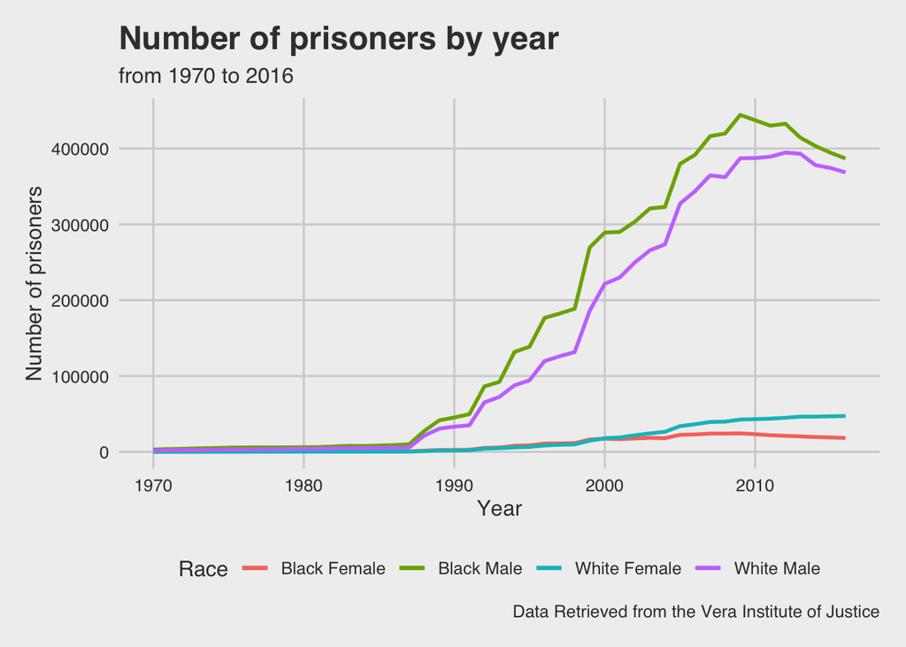

My first chart tracks the number of prisoners in our justice system by each year. Four variables are tracked here, the first two are the number of Black males and White males that greatly increase in number shortly after 1990. The problem with these two lines is that Black males surpass White males. Going back to my `imaginary group 1` analogy, one could argue that Black males are simply more violent than White males, and therefore they are jailed more, the same way that females are underrepresented in the prisoner population than males. However, I would argue that men are more similar to each other in terms of aggression than women. That is why there are more White women in prison than there are Black women. The problem lies with who people police Black people.

## Variable Comparison Chart

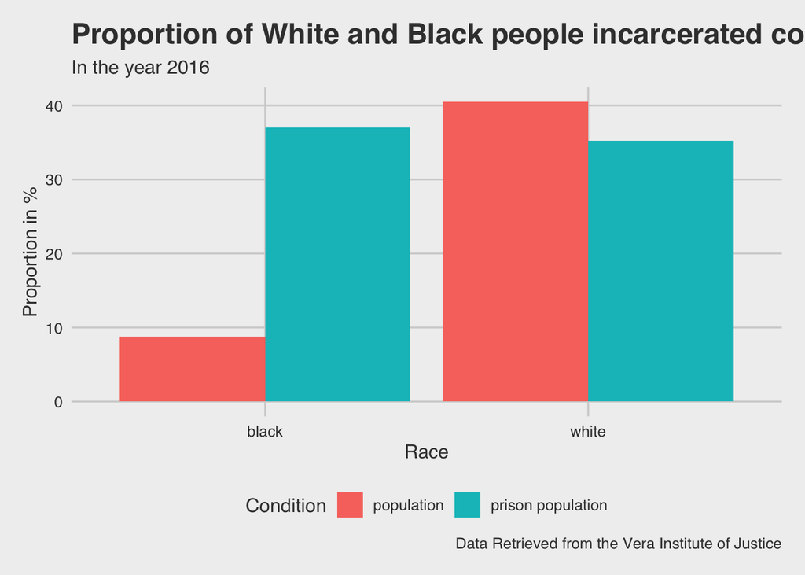

My second chart shows this problem with policing more clearly. Black and White people make up wildly different percentages in the overall population, as shown with the red bar. However, they make up roughly similar percentages in the over all prisoner population! With this graph we can clearly see the injustice of our policing system at work. We systematically lock up Black people at an incredibly higher rate than White people.

## Map

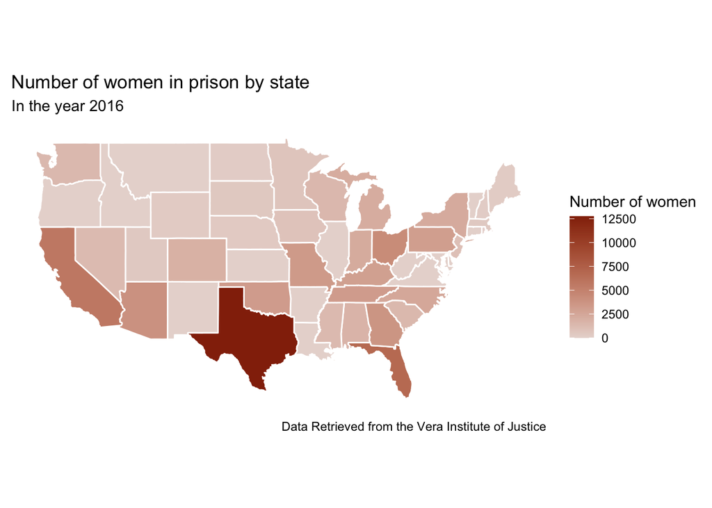

Lastly, this map shows the breakdown of women in jail according to state in 2016. Something to note is the overall low number of women in prison regardless of state. While it would be expected that the highest populated states also have the highest number of women in prison, that isn’t exactly the case either. The only state that seemingly pushes for accountability in women’s actions is Texas. It seems like most states do not ferocity in conviction toward women that they do toward men.